# Titanic Passengers

## “Women and Children First”

Everyone’s favorite garden variety [dataset](https://view.officeapps.live.com/op/view.aspx?src=http%3A%2F%2Fbiostat.mc.vanderbilt.edu%2Fwiki%2Fpub%2FMain%2FDataSets%2Ftitanic3.xls)! Using data from 1309 individuals, the following visualizations attempt to illustrate how the ship’s crew prioritized its passengers. Does the sinking of the Titanic deserve to be so famously associated with the phrase “women and children first”?

#### Adult survivor distribution based on SES status and gender

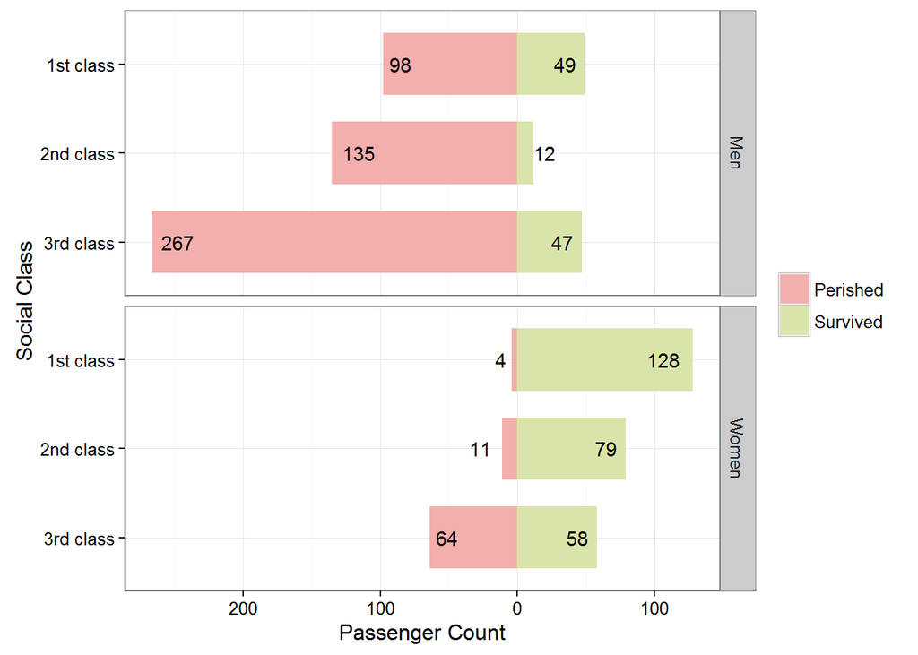

The most striking aspect of this plot is the disproportionate number of deaths among men, who occupy a whopping 86% of the ship’s total adult death count. It’s interesting to note that while a large majority (85%) of adult males in the bottom class perished, middle class passengers actually exceed this percentage with 92% of adult males dying. Not even a higher class disctinction was enough to guarantee men a spot on a lifeboat, it seems. The distribution among women passengers is an entirely different picture. Unlike adult males, first and second class females enjoyed top priority, with their combined death count comprising only 19% of all adult female deaths.

#### Child (age < 13 years) survivor distribution based on SES status

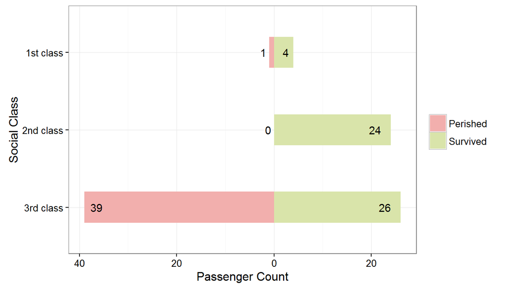

The majority of children belonged to the bottom class, with first class reserved for an exclusive 5% of children. The group’s survival mirrors that of women’s; no deaths occurred in second class, and only 1 child died in first class. Likewise, the high number of deaths in third class is, sadly, similar to the fates of the women.

Titanic passengers and crew members rightfully earned their reputation for upholding the “women and children first” principle. Perhaps a more accurate description of the procedure, however, would be “men last”. Men received the short end of the stick en masse, whereas women–and their children–were still prioritized by class.